# UC4-25 TD 3D

## UC4-25-TD-3D

Travail Dirigé - UC4-25 Télédétection forestière - Altimétrie laser à balayage et structure 3D des forêts

### Objectif

Apprendre à manipuler des données Lidar, en extraire des informations d’intérêt pour modéliser des attributs forestiers liés à la structure des forêts, comme la surface terrière ou le volume.

La première partie du TD sera consacrée à la manipulation de nuages de points lidar. Nous exploiterons pour cela une tuile du programme lidar HD.

Dans un second temps, un travail sur la création de modèles numérique et la normalisation des nuages de point du sursol sera effectué.

La troisième partie portera sur l’extaction de descripteurs de la canopée, avec des approaches surfaciques et objet.

Finalement, la dernière partie du TD visera à construire un modèle prédictif d’attributs forestiers. Compte tenu de l’emprise spatiale des données, elle exploitera un fichier de données généré au préalable à partir de données IFN et d’un vol Lidar sur les Vosges.

### Partie 1 : manipulation de données Lidar

1. Charger les librairies

```r
library(terra)
library(leaps)
library(lidR)
# help ("lidR")
```

2. Ouvrir le nuage de point las en utilisant la fonction readLAS

Il est possible d’obtenir des informations supplémentaires sur la fonction readLAS avec le code suivant: ?lidR::readLAS

```r
las <- readLAS(...)
```

3. Explorer le fichier las

Afficher les élements suivants : . dimensions du fichier (nombre de lignes et de colonnes) . nom des attributs . étendue spatiale du fichier

Vous devriez obtenir les résultats suivants:

```
## [1] "Nombre de lignes : 30155000"
```

```
## [1] "Nombre de colonnes : 18"
```

```
## [1] "Attributs : X Y Z gpstime Intensity ReturnNumber NumberOfReturns ScanDirectionFlag EdgeOfFlightline Classification ScannerChannel Synthetic_flag Keypoint_flag Withheld_flag Overlap_flag ScanAngle UserData PointSourceID"
```

```
## [1] "Etendue spatiale : 613000 6515000 613999.99 6515999.99"
```

4. Explorer le champ “classification”

Générer une table et un histogramme en adaptant le code suivant :

```r
table(...)
hist(...)
```

5. Découpage de données

Le fichier d’origine étant assez lourd à manipuler, nous allons travailler sur un sous-échantillon de 100 x 100 m.

Vous pouvez pour cela utiliser une des deux fonctions suivantes de lidR : clip_roi et clip_rectangle.

La première permet d’utiliser une géométrie comme une bounding box.

La seconde nécessaire la saisie des coordonnées de la bounding box : xleft, ybottom, xright, ytop.

Le choix de la zone importe peu.

Afficher le résultat avec la fonction plot

6.Afficher le nuage de point avec différentes options

Colorer le nuage de point selon la classification, le nombre de retour, et l’intensité

Utiliser l’option “color” de la fonction plot. Se référer aux noms des attributs pour préciser le nom à utiliser.

Que remarquez vous pour l’intensité? Explorer les options de la fonction plot pour proposer une solution.

### Partie 2 : Generation de modèles numériques et normalisation du sursol

1. Generation d’un modèle numérique de terrain.

Utiliser la fonction rasterize_terrain pour générer un modèle numérique de terrain avec un algorithme de type TIN.

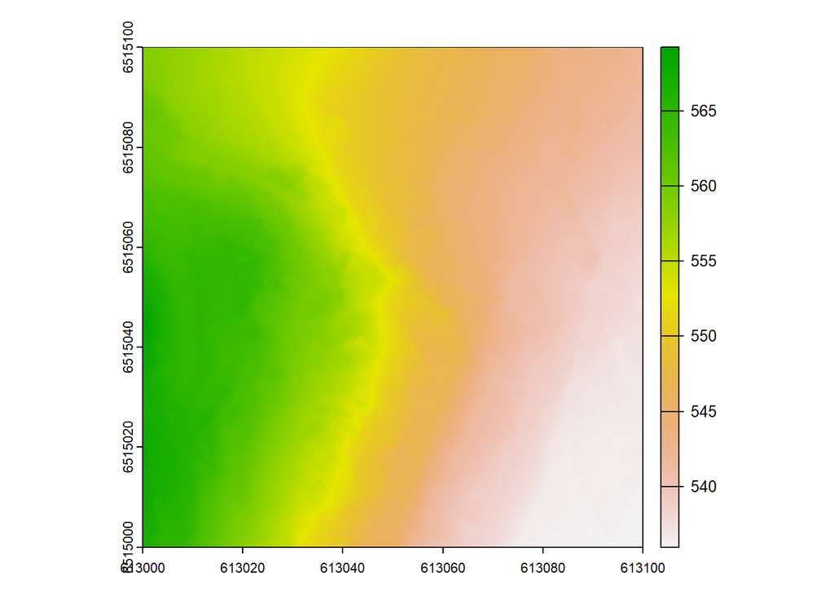

```r
ting <- lidR::rasterize_terrain(clip_las, res = 0.5, algorithm = tin())
plot(ting)
```

2. Generation d’un effet d’ombrage

Pour mieux visualiser le relief, génèrer un effet d’ombrage avec les fonctions terrain et shade de la librairie Terra.

La fonction terrain permet de générer un modèle de pente et d’orientation de pente.

La fonction shade permet de génèrer l’ombrage.

Dans la fonction plot, l’échelle de couleur grise permet de mieux appréhender le relief.

```r
tin_deriv <- terrain(ting, v = c("slope", "aspect"), unit = "radians")
tin_shade <- shade(slope = tin_deriv$slope, aspect = tin_deriv$aspect)
plot(tin_shade)
plot(tin_shade, col =gray(0:30/30), legend = FALSE)
```

On constate que lidR est allé chercher les points sol.

3. Comparaison d’algorithmes

Générer un nouvel MNT en utilisant un autre algorithme, par exemple “knnidw”.

Utiliser l’aide de la fonction pour préciser les options.

Calculer la difference entre les deux modèles et afficher le résultat. Qu’observez-vous?

4. Génération d’un modèle numérique de surface

Utiliser la fonction rasterize_canopy. Explorer les options de la fonction pour compléter le code.

```r
dsm <- lidR::rasterize_canopy(clip_las, res = 0.5, ...)
col <- height.colors(25)
plot(dsm, col = col)
```

5. Génération d’un modèle numérique de canopée

Pour calculer la hauteur de la canopée, il suffit de soustraire le MNT au DSM

```r
chm <- dsm - ting
col <- height.colors(25)
plot(chm, col = col)
```

6. Normalisation de nuage de points

On peut aussi normaliser le nuage de points à partir du MNT Utsliser la fonction normalize_height

7. Extraction de points d’intérêt du nuage

lidR permets de filter les nuages de point à l’ouverture du fichier, grâce à l’option filter: readLAS(files, select = “*“, filter =”“)

L’argument “select” permet de sélectionner des attributs. select = “*xyzia” selectionnera les coordonnées x,y,z, l’intensité et l’angle de scan

L’argument “filter” agit sur les lignes. L’ensemble des filtre disponibles peut-être obtenus avec la fonction readLAS(filter = “-help”)

Par exemple pour ne lire que les premiers retours d’un fichier: las <- readLAS(“fichier”, filter = “-keep_first”)

On peut aussi travailler à partir d’un nuage de point déjà chargé, avec la fonction filter_poi. poi = point of interest

Compléter le code suivant pour sélectionner les premiers retours :

```r
clip_first <-  filter_poi(clip_las_h, ...)
plot(clip_first)
```

## Partie 3 : extraction de descripteur de la canopée

1. descripteurs surfaciques

Décrire les propriétés du nuage de points sur une emprise spatiale donnée.

Dans le cadre d’un inventaire, l’emprise est celle de la placette d’inventaire.

lidR inclut un certains nombre de “métriques” (ou variables) pré-définis

Il sont de trois natures :

- nuage de point
- raster
- voxel : espace 3D

Le code suivant permet d’extraire des métriques du nuage de point

```r
cmetric <-  cloud_metrics(clip_las_h, func = .stdmetrics)
```

Le résultat est une liste de 56 métriques.On peut la convertir en tableau. Dans le code suivant, “sapply” convertit la liste en matrice, et “data.frame” la matrice en tableau.

Vous pouvez appliquer le même code aux premiers retours pour voir les différences.

```r
cmetric <-  data.frame(t(sapply(cmetric,c)))
cmetric
```

| zmax | zmean | zsd | zskew | zkurt | zentropy | pzabovezmean | pzabove2 | zq5 | zq10 | zq15 | zq20 | zq25 | zq30 | zq35 | zq40 | zq45 | zq50 | zq55 | zq60 | zq65 | zq70 | zq75 | zq80 | zq85 | zq90 | zq95 | zpcum1 | zpcum2 | zpcum3 | … |
| --- | --- | --- | --- | --- | --- | --- | --- | --- | --- | --- | --- | --- | --- | --- | --- | --- | --- | --- | --- | --- | --- | --- | --- | --- | --- | --- | --- | --- | --- | --- |
| 36.47 | 10.40019 | 9.88123 | 0.4589663 | 1.832216 | NA | 44.70004 | 64.88344 | -0.03 | -0.01 | 0.01 | 0.04 | 0.17 | 0.91 | 1.97 | 3.96 | 6.33 | 8.32 | 10.29 | 12.65 | 15.16 | 17.38 | 19.26 | 20.95 | 22.67 | 24.78 | 27.58 | 30.024 | 39.07596 | 49.86602 | … |

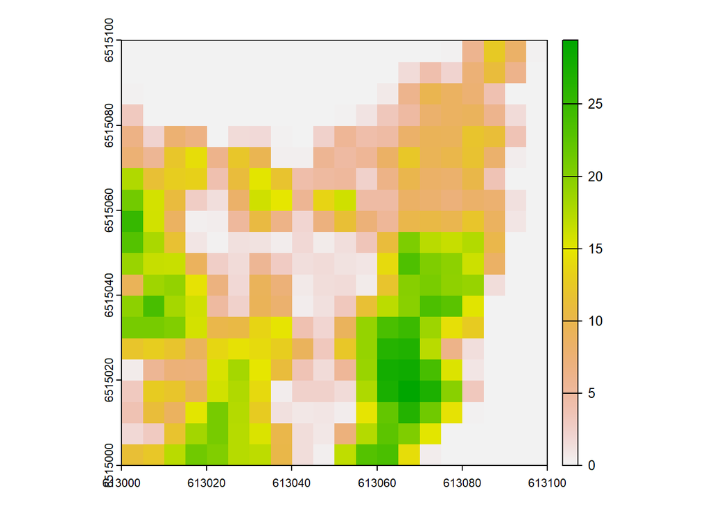

```r
pmetric <-  pixel_metrics(clip_las_h, mean(Z), 5)
plot(pmetric)
```

```r
summary(pmetric)
```

```
##        V1
##  Min.   :-0.000373
##  1st Qu.: 0.213920
##  Median : 5.993959
##  Mean   : 7.735890
##  3rd Qu.:13.345014
##  Max.   :29.420418
```

Ecrire un code permettant d’effectuer le même calcul sur les premiers retours

lidR permet aussi d’inclure ses propres fonctions. Dans l’exemple suivant, on calcule la moyenne des intensités

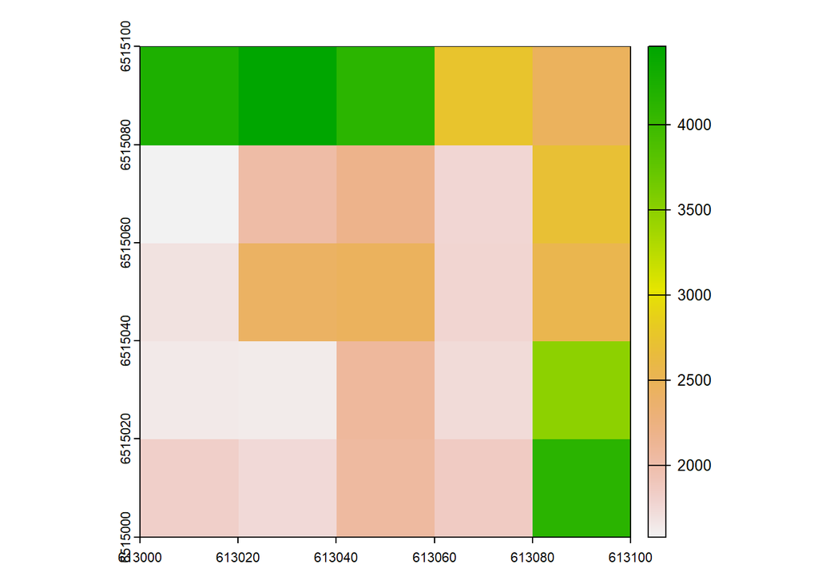

```r
f <- function(i) {
  list(
    mean = mean(i))
}

pmetric <- pixel_metrics(clip_las_h, func = ~f(Intensity))
plot(pmetric)
```

Ecrivez une fonction qui calcule la moyenne des z et l’écart type de l’intensité

2. descripteurs objet

La fonction “segment_trees” de lidR permet de segmenter le nuage en couronnes d’arbre individuelles.

Elle inclut plusieurs algorithmes.

Dans l’exemple suivant, on utlise l’algorithme de Dalponte (2016). Les paramètres de l’algorithme sont - un CHM - un jeu de position d’arbre - plusieurs seuils qui contraigent la croissance de la couronnes)

Pour générer le jei de position d’arbre, on utilise un filtre de maxima locaux avec taille de fenêtre variable La taille de la fenêtre augmente avec la hauteur:

```r
f <- function(x) {x * 0.1 + 3}
heights <- seq(0,30,5)
ws <- f(heights)
```

Ensuite, on localise les apex d’arbres. La fonction prend soit le nuage de point soit le CHM

```r
apex <- locate_trees(clip_las_h, lmf(f))
```

On visualise le résultat

```r
plot(chm, col = height.colors(50))
plot(sf::st_geometry(apex), add = TRUE, pch = 3)
```

On segmente ensuite le nuage de point par croissance de region depuis les maxima locaux

```r
algo <- dalponte2016(chm, apex)
trees <- segment_trees(clip_las_h, algo)
plot(trees, bg = "white", size = 4, color = "treeID")
```

On peut raffiner les résultats en jouant sur la détection des maxima locaux ainsi que sur les paramètres de l’algorithme. Dans l’exemple suivant, on lisse le CHM avec un filtre median :

```r
kernel <- matrix(1,3,3)
chm_smooth <- terra::focal(chm, w = kernel, fun = median, na.rm = TRUE)
apex <- locate_trees(chm_smooth, lmf(f))

plot(chm_smooth, col = height.colors(50))
plot(sf::st_geometry(apex), add = TRUE, pch = 3)

algo <- dalponte2016(chm_smooth, apex)
trees <- segment_trees(clip_las_h, algo)
plot(trees, bg = "white", size = 4, color = "treeID")
```

On compare les résultats avec un autre algorithme: li 2012 Cet algorithme traite directement le nuage de point et ne nécessite pas d’identification préalable de maxima locaux

```r
algo <- li2012()
trees <- segment_trees(clip_las_h, algo)
plot(trees, bg = "white", size = 4, color = "treeID")
```

Qu’observez-vous?

On termine par une extraction de métrique par objet. Dans l’exemple suivant, la hauteur moyenne et maximale de chaque couronne.

```r
metrics <- crown_metrics(trees, ~list(z_max = max(Z), z_mean = mean(Z)))
head(metrics)
```

## Partie 4 : modélisation d’attributs forestiers

Le jeux de données contient des données de volume et de surface terrière pour un ensemble de placettes IFN et des métriques lidar extraites pour chaque placette, sur une surface circulaire de 15 m de rayon. Les métriques lidar sont les suivantes: Perc10 à Perc95: des percentiles de hauteur, pour tous les points au dessus de 2 m Cum1 à Cum9 : les pourcentages cummulés de retours au dans la ieme couche (d1, d2 dans https://doi.org/10.5558/tfc84827-6)

Objectif : développer un modèle de prédiction du volume et/ou de la surface terrière par un modèle linéaire simple. Etapes : selectionner le meilleur modèle à partir de l’ensemble des modèles, appliquer une approche de validation croisé et de test.

1. Lecture du fichier

```r
plots <- read.csv("plots.csv")
head(plots)
```

|  | ID | volume | SurfTerr | Perc10 | Perc15 | Perc20 | Perc25 | Perc30 | Perc35 | Perc40 | Perc45 | Perc50 | Perc55 | Perc60 | Perc65 | Perc70 | Perc75 | Perc80 | Perc85 | Perc90_ | Perc95 | Cum1 | Cum2 | Cum3 | Cum4 | Cum5 | Cum6 | Cum7 | Cum8 | … |
| --- | --- | --- | --- | --- | --- | --- | --- | --- | --- | --- | --- | --- | --- | --- | --- | --- | --- | --- | --- | --- | --- | --- | --- | --- | --- | --- | --- | --- | --- | --- |
| 1 | 1 | 524.04654 | 41.33879 | 4.940 | 7.3950 | 10.94 | 14.240 | 16.840 | 19.175 | 20.370 | 21.545 | 22.59 | 23.41 | 24.140 | 24.940 | 25.580 | 26.325 | 26.990 | 27.7400 | 28.630 | 29.860 | 5.4457831 | 14.530120 | 19.542169 | 24.91566 | 31.61446 | 43.44578 | 63.25301 | 87.63855 | … |
| 2 | 2 | 458.59910 | 34.22613 | 12.880 | 15.1135 | 17.12 | 18.600 | 19.830 | 20.850 | 21.670 | 22.450 | 23.13 | 23.74 | 24.414 | 25.130 | 25.770 | 26.450 | 27.230 | 28.0565 | 28.950 | 30.130 | 1.3044862 | 3.192279 | 6.331530 | 11.53887 | 20.12939 | 34.04391 | 57.42921 | 81.38721 | … |
| 3 | 3 | 568.48330 | 56.66954 | 7.650 | 9.2450 | 10.42 | 11.360 | 12.310 | 13.160 | 13.870 | 14.660 | 15.27 | 15.97 | 16.690 | 17.360 | 18.070 | 18.780 | 19.610 | 20.5600 | 21.650 | 23.030 | 0.8011653 | 5.120175 | 12.017480 | 23.44501 | 39.92717 | 59.62855 | 78.73999 | 92.06846 | … |
| 4 | 4 | 97.43798 | 18.99161 | 4.190 | 4.9100 | 5.51 | 6.020 | 6.480 | 6.984 | 7.480 | 7.930 | 8.39 | 8.82 | 9.280 | 9.756 | 10.250 | 10.830 | 11.470 | 12.2040 | 13.136 | 14.350 | 0.0000000 | 5.322862 | 16.775742 | 33.55148 | 51.87609 | 70.04799 | 83.74782 | 92.62653 | … |
| 5 | 5 | 451.21294 | 54.20199 | 6.096 | 7.4190 | 8.48 | 9.515 | 10.668 | 11.581 | 12.534 | 13.387 | 14.16 | 14.88 | 15.580 | 16.200 | 16.852 | 17.450 | 18.118 | 18.7500 | 19.454 | 20.457 | 0.7870143 | 6.443679 | 13.649779 | 24.96311 | 36.47319 | 50.86080 | 68.51943 | 86.91589 | … |
| 6 | 6 | 351.34396 | 35.57499 | 10.500 | 11.8190 | 12.78 | 13.590 | 14.370 | 14.890 | 15.530 | 16.120 | 16.67 | 17.22 | 17.750 | 18.240 | 18.762 | 19.320 | 19.880 | 20.5300 | 21.240 | 22.340 | 0.2486531 | 2.631579 | 5.242437 | 11.33444 | 25.40406 | 47.32698 | 73.24907 | 93.30709 | … |

Calcul des modèles pour le volume. On commence par supprimer la surface terrière du tableau

```r
volume <- plots[,-c(3)]
models <- regsubsets(volume~., data = volume, nvmax = 5)
summary(models)
```

Que représentent ces variables selon vous?

On veut tester le modèle en validation croisée: k-fold

On commence par générer les échantillon et le vecteur pour stocker les erreurs

```r
K=10
folds = sample(1:K, nrow(volume), replace=TRUE)
err = rep(NA,K)
```

Ensuite, on itère pour chaque échantillon la construction du modèle, son évaluation sur les données non utilisées Et on calcule l’erreur quadratique moyenne

```r
for (i in 1:K){
  # on selectionne l'échantillon k
  fold_i = which(folds==i)

  # on génère un jeu d'entrainement et de test
  volumeApp = volume[-fold_i,]
  volumeTest = volume[fold_i,]

  # on entraine le modèle linéaire
  App = lm(volume~., data=volumeApp)

  # on le teste sur le jeu d'évaluation
  Pred = predict(App, volumeTest)

  # on calcule l'erreur de prédiction et on l'assigne au vecteur de sortie
  err[i] = sqrt(mean((Pred - volumeTest$volume)^2))
}

# on calcule l'erreur moyenne et l'écart type de l'erreur sur les k folds
mean(err)
sd(err)

# on passe en pourcentage
mean(err)/mean(volume$volume)*100
```

Répéter l’opération avec différents modèles et trouver celui qui minimise l’erreur.